# R - Konfidenzintervalle und Hypothesentests

Dr. Katja Nieberle

2026-03-15

## Konfidenzintervalle

Konfidenzintervalle geben einen Plausibilitätsbereich für den unbekannten Populationsmittelwert $\mu$ an.

**Interpretation** eines 95%-Konfidenzintervalls: Für die gegebene Stichprobe überdeckt das berechnete Intervalle den wahren $\mu$ mit 95%-ger Wahrscheinlichkeit.

1. Für **Große Stichproben** ($n \gtrsim 30$) mit der unbekannten Varianz der Grundgesamtheit (die Varianz der Stichprobe ist bekannt) lautet das *zweiseitige* symmetrische Konfidenzintervall

$$\overline{x} \mp z_{1-\alpha/2} \cdot
\frac{s}{\sqrt{n}}$$

2. Für **Kleine Stichproben** ($n < 30$) mit der unbekannten Varianz der Grundgesamtheit (die Varianz der Stichprobe ist bekannt) lautet das *zweiseitige* symmetrische Konfidenzintervall

$$\overline{x} \mp t_{n-1,1-\alpha/2}
\cdot \frac{s}{ \sqrt{n}}$$
### Beispiel: Konfidenzintervall für Große Stichprobe

```r
alpha <- 0.05
# Stichprobe groß (n = 200)
x_gross <- c(98, 102, 99, 101, 103, 97, 104, 100, 105, 96, 107, 99, 102, 98, 101,
             103, 99, 100, 104, 97)
x_gross <- rep(x_gross, length.out = 200)
n_gross <- length(x_gross)
xbar_gross <- mean(x_gross)
s_gross <- sd(x_gross)
se_gross <- s_gross / sqrt(n_gross)
z_crit <- qnorm(1 - alpha/2)

ci_gross <- c(xbar_gross - z_crit * se_gross,
              xbar_gross + z_crit * se_gross)
print("Untergrenze: ")
```

```
## [1] "Untergrenze: "
```

```r
print(ci_gross[1])
```

```
## [1] 100.3476
```

```r
print("Obergrenze: ")
```

```
## [1] "Obergrenze: "
```

```r
print(ci_gross[2])
```

```
## [1] 101.1524
```

### Beispiel: Konfidenzintervall für Kleine Stichprobe

```r
alpha <- 0.05
# Stichprobe klein (n = 15)
x_klein <- c(92, 98, 105, 95, 110, 102, 99, 104, 97, 101, 103, 96, 108, 100, 106)
n_klein <- length(x_klein)
xbar_klein <- mean(x_klein)
s_klein <- sd(x_klein)
se_klein <- s_klein / sqrt(n_klein)
t_crit_klein <- qt(1 - alpha/2, df = n_klein - 1)

ci_klein <- c(xbar_klein - t_crit_klein * se_klein,
              xbar_klein + t_crit_klein * se_klein)
print("Untergrenze: ")
```

```
## [1] "Untergrenze: "
```

```r
print(ci_klein[1])
```

```
## [1] 98.27047
```

```r
print("Obergrenze: ")
```

```
## [1] "Obergrenze: "
```

```r
print(ci_klein[2])
```

```
## [1] 103.8629
```

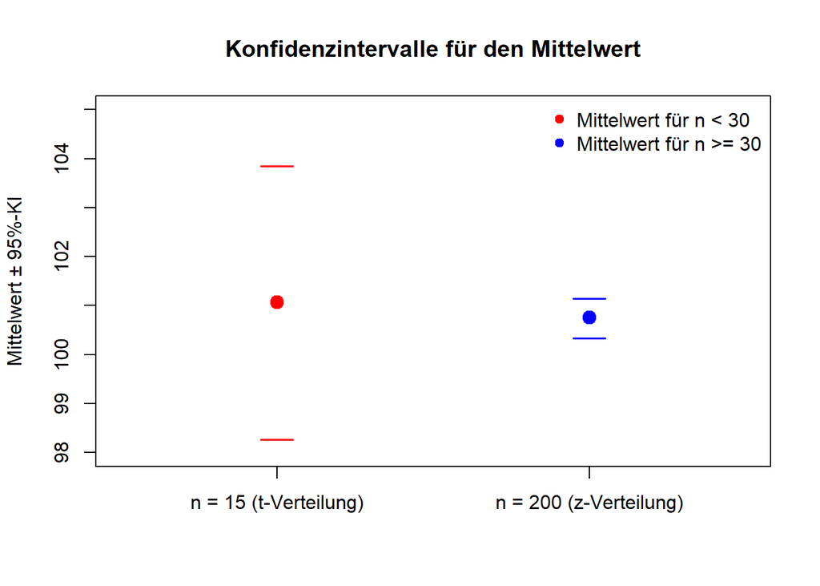

### Wovon hängt die Breite eines Konfidenzintervalls ab?

*Beispiel*: Für eine Stichprobe von Verspätungszeiten mit dem Mittelwert $\overline{x} = 10$ soll ein zweiseitiges Konfidenzintervall aufgestellt werden.

1. Untersucht die Breite des Konfidenzintervalls, wenn bekannt ist, dass die Standardabweichung der Stichprobe $s = 2$ min, das Konfidenzniveau $95\%$ beträgt und der Umfang der Stichprobe a) $n = 10$ b) $n = 100$ c) $n = 1000$ beträgt.
2. Untersucht die Breite des Konfidenzintervalls, wenn bekannt ist, dass der Umfang der Stichprobe $n = 100$, das Konfidenzniveau $95\%$ beträgt und Standardabweichung der Stichprobe a) $s = 2$ b) $s = 5$ c) $s = 10$ beträgt.
3. Untersucht die Breite des Konfidenzintervalls, wenn bekannt ist, dass der Umfang der Stichprobe $n = 100$, die Standardabweichung $s = 3$ beträgt und das Konfidenzniveau a) $90\%$ b) $95\%$ c) $99\%$ beträgt.

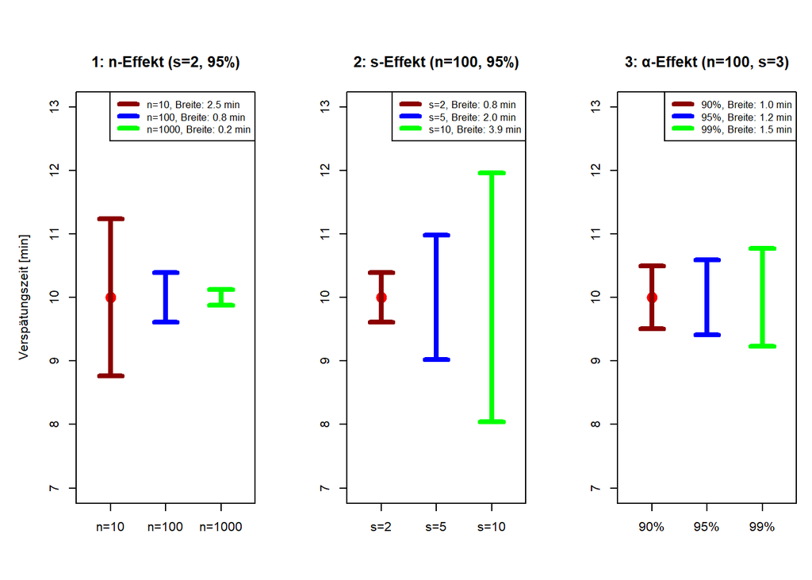